# Pension returns analysis

07:13 29 May 2024

Fit log returns to F-S skew standardized Student-t distribution.  
`m` is the location parameter.  
`s` is the scale parameter.  
`nu` is the estimated shape parameter (degrees of freedom).  
`xi` is the estimated skewness parameter.

# Returns data 2011-2023.

For 2011, medium risk data is used in the high risk data set, as no high risk fund data is available prior to 2012.  
`vmrl` is a long version of Velliv medium risk data, from 2007 to 2023. For 2007 to 2011 (both included) no high risk data is available.

PFA medium risk is risk profile B.  
PFA high risk is risk profile D.

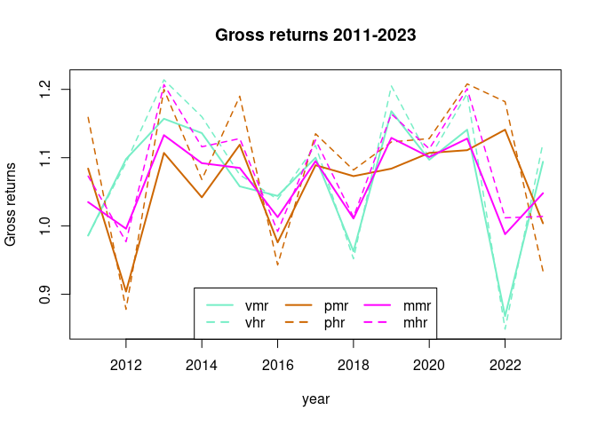

## Summary of log-returns

The summary statistics are transformed back to the scale of gross returns by taking $exp()$ of each summary statistic. (Note: Taking arithmetic mean of gross returns directly is no good. Must be geometric mean.)

|  | vmr | vhr | pmr | phr | mmr | mhr | vmr_phr | vhr_pmr |
| --- | --- | --- | --- | --- | --- | --- | --- | --- |
| Min. : | 0.868 | 0.849 | 0.904 | 0.878 | 0.988 | 0.977 | 0.979 | 0.967 |
| 1st Qu.: | 1.044 | 1.039 | 1.042 | 1.068 | 1.013 | 1.013 | 1.021 | 1.011 |
| Median : | 1.097 | 1.099 | 1.084 | 1.128 | 1.085 | 1.113 | 1.102 | 1.094 |
| Mean : | 1.067 | 1.080 | 1.063 | 1.089 | 1.064 | 1.085 | 1.079 | 1.072 |
| 3rd Qu.: | 1.136 | 1.160 | 1.107 | 1.182 | 1.101 | 1.128 | 1.121 | 1.107 |
| Max. : | 1.168 | 1.214 | 1.141 | 1.208 | 1.133 | 1.207 | 1.178 | 1.163 |

## Ranking

| Min. : | ranking | 1st Qu.: | ranking | Median : | ranking | Mean : | ranking | 3rd Qu.: | ranking | Max. : | ranking |
| --- | --- | --- | --- | --- | --- | --- | --- | --- | --- | --- | --- |
| 0.988 | mmr | 1.068 | phr | 1.128 | phr | 1.089 | phr | 1.182 | phr | 1.214 | vhr |
| 0.979 | vmr_phr | 1.044 | vmr | 1.113 | mhr | 1.085 | mhr | 1.160 | vhr | 1.208 | phr |
| 0.977 | mhr | 1.042 | pmr | 1.102 | vmr_phr | 1.080 | vhr | 1.136 | vmr | 1.207 | mhr |
| 0.967 | vhr_pmr | 1.039 | vhr | 1.099 | vhr | 1.079 | vmr_phr | 1.128 | mhr | 1.178 | vmr_phr |
| 0.904 | pmr | 1.021 | vmr_phr | 1.097 | vmr | 1.072 | vhr_pmr | 1.121 | vmr_phr | 1.168 | vmr |
| 0.878 | phr | 1.013 | mmr | 1.094 | vhr_pmr | 1.067 | vmr | 1.107 | pmr | 1.163 | vhr_pmr |
| 0.868 | vmr | 1.013 | mhr | 1.085 | mmr | 1.064 | mmr | 1.107 | vhr_pmr | 1.141 | pmr |
| 0.849 | vhr | 1.011 | vhr_pmr | 1.084 | pmr | 1.063 | pmr | 1.101 | mmr | 1.133 | mmr |

## Correlations and covariance

Correlations

|  | vmr | vhr | pmr | phr |
| --- | --- | --- | --- | --- |
| vmr | 1.000 | 0.993 | -0.197 | -0.095 |
| vhr | 0.993 | 1.000 | -0.119 | -0.016 |
| pmr | -0.197 | -0.119 | 1.000 | 0.957 |
| phr | -0.095 | -0.016 | 0.957 | 1.000 |

Covariances

|  | vmr | vhr | pmr | phr |
| --- | --- | --- | --- | --- |
| vmr | 0.007 | 0.009 | -0.001 | -0.001 |
| vhr | 0.009 | 0.011 | -0.001 | 0.000 |
| pmr | -0.001 | -0.001 | 0.004 | 0.007 |
| phr | -0.001 | 0.000 | 0.007 | 0.011 |

# Compare pension plans

## Risk of loss

Risk of loss at least as big as row name in percent for a single period (year).

Skewed $t$-distribution (sstd):

|  | vmr | vhr | pmr | phr | mmr | mhr | vmr_phr | vhr_pmr |
| --- | --- | --- | --- | --- | --- | --- | --- | --- |
| 0 | 21.167 | 21.333 | 11.833 | 14.000 | 12.333 | 12.667 | 16.667 | 16.000 |
| 5 | 12.167 | 13.167 | 5.667 | 8.333 | 5.833 | 3.833 | 8.667 | 8.167 |
| 10 | 7.000 | 8.000 | 3.000 | 5.000 | 2.833 | 0.500 | 4.333 | 4.167 |
| 25 | 1.333 | 1.500 | 0.500 | 1.000 | 0.333 | 0.000 | 0.333 | 0.333 |
| 50 | 0.000 | 0.000 | 0.000 | 0.000 | 0.000 | 0.000 | 0.000 | 0.000 |
| 90 | 0.000 | 0.000 | 0.000 | 0.000 | 0.000 | 0.000 | 0.000 | 0.000 |
| 99 | 0.000 | 0.000 | 0.000 | 0.000 | 0.000 | 0.000 | 0.000 | 0.000 |

Standardized $t$-distribution (std):

|  | vmr | vhr | pmr | phr | mmr | mhr | vmr_phr | vhr_pmr |
| --- | --- | --- | --- | --- | --- | --- | --- | --- |
| 0 | 17.333 | 20.333 | 8.833 | 26.667 | 11.667 | 14.333 | 13.500 | 15.000 |
| 5 | 7.667 | 10.333 | 4.333 | 14.500 | 1.000 | 3.500 | 2.667 | 2.833 |
| 10 | 3.000 | 4.667 | 2.333 | 6.333 | 0.000 | 0.167 | 0.000 | 0.000 |
| 25 | 0.000 | 0.000 | 0.333 | 0.000 | 0.000 | 0.000 | 0.000 | 0.000 |
| 50 | 0.000 | 0.000 | 0.000 | 0.000 | 0.000 | 0.000 | 0.000 | 0.000 |
| 90 | 0.000 | 0.000 | 0.000 | 0.000 | 0.000 | 0.000 | 0.000 | 0.000 |
| 99 | 0.000 | 0.000 | 0.000 | 0.000 | 0.000 | 0.000 | 0.000 | 0.000 |

Normal distribution:

|  | vmr | vhr | pmr | phr | mmr | mhr | vmr_phr | vhr_pmr |
| --- | --- | --- | --- | --- | --- | --- | --- | --- |
| 0 | 21.167 | 21.667 | 16.500 | 19.667 | 9.333 | 12.0 | 10.833 | 12.000 |
| 5 | 7.333 | 9.500 | 3.333 | 8.500 | 0.500 | 2.5 | 1.667 | 1.833 |
| 10 | 1.500 | 2.833 | 0.000 | 2.667 | 0.000 | 0.0 | 0.000 | 0.000 |
| 25 | 0.000 | 0.000 | 0.000 | 0.000 | 0.000 | 0.0 | 0.000 | 0.000 |
| 50 | 0.000 | 0.000 | 0.000 | 0.000 | 0.000 | 0.0 | 0.000 | 0.000 |
| 90 | 0.000 | 0.000 | 0.000 | 0.000 | 0.000 | 0.0 | 0.000 | 0.000 |
| 99 | 0.000 | 0.000 | 0.000 | 0.000 | 0.000 | 0.0 | 0.000 | 0.000 |

### Worst ranking for loss percentiles

Skewed $t$-distribution (sstd):

| 0 | ranking | 5 | ranking | 10 | ranking | 25 | ranking | 50 | ranking | 90 | ranking | 99 | ranking |
| --- | --- | --- | --- | --- | --- | --- | --- | --- | --- | --- | --- | --- | --- |
| 21.333 | vhr | 13.167 | vhr | 8.000 | vhr | 1.500 | vhr | 0 | vmr | 0 | vmr | 0 | vmr |
| 21.167 | vmr | 12.167 | vmr | 7.000 | vmr | 1.333 | vmr | 0 | vhr | 0 | vhr | 0 | vhr |
| 16.667 | vmr_phr | 8.667 | vmr_phr | 5.000 | phr | 1.000 | phr | 0 | pmr | 0 | pmr | 0 | pmr |
| 16.000 | vhr_pmr | 8.333 | phr | 4.333 | vmr_phr | 0.500 | pmr | 0 | phr | 0 | phr | 0 | phr |
| 14.000 | phr | 8.167 | vhr_pmr | 4.167 | vhr_pmr | 0.333 | mmr | 0 | mmr | 0 | mmr | 0 | mmr |
| 12.667 | mhr | 5.833 | mmr | 3.000 | pmr | 0.333 | vmr_phr | 0 | mhr | 0 | mhr | 0 | mhr |
| 12.333 | mmr | 5.667 | pmr | 2.833 | mmr | 0.333 | vhr_pmr | 0 | vmr_phr | 0 | vmr_phr | 0 | vmr_phr |
| 11.833 | pmr | 3.833 | mhr | 0.500 | mhr | 0.000 | mhr | 0 | vhr_pmr | 0 | vhr_pmr | 0 | vhr_pmr |

Standardized $t$-distribution (std):

| 0 | ranking | 5 | ranking | 10 | ranking | 25 | ranking | 50 | ranking | 90 | ranking | 99 | ranking |
| --- | --- | --- | --- | --- | --- | --- | --- | --- | --- | --- | --- | --- | --- |
| 26.667 | phr | 14.500 | phr | 6.333 | phr | 0.333 | pmr | 0 | vmr | 0 | vmr | 0 | vmr |
| 20.333 | vhr | 10.333 | vhr | 4.667 | vhr | 0.000 | vmr | 0 | vhr | 0 | vhr | 0 | vhr |
| 17.333 | vmr | 7.667 | vmr | 3.000 | vmr | 0.000 | vhr | 0 | pmr | 0 | pmr | 0 | pmr |
| 15.000 | vhr_pmr | 4.333 | pmr | 2.333 | pmr | 0.000 | phr | 0 | phr | 0 | phr | 0 | phr |
| 14.333 | mhr | 3.500 | mhr | 0.167 | mhr | 0.000 | mmr | 0 | mmr | 0 | mmr | 0 | mmr |
| 13.500 | vmr_phr | 2.833 | vhr_pmr | 0.000 | mmr | 0.000 | mhr | 0 | mhr | 0 | mhr | 0 | mhr |
| 11.667 | mmr | 2.667 | vmr_phr | 0.000 | vmr_phr | 0.000 | vmr_phr | 0 | vmr_phr | 0 | vmr_phr | 0 | vmr_phr |
| 8.833 | pmr | 1.000 | mmr | 0.000 | vhr_pmr | 0.000 | vhr_pmr | 0 | vhr_pmr | 0 | vhr_pmr | 0 | vhr_pmr |

Normal distribution:

| 0 | ranking | 5 | ranking | 10 | ranking | 25 | ranking | 50 | ranking | 90 | ranking | 99 | ranking |
| --- | --- | --- | --- | --- | --- | --- | --- | --- | --- | --- | --- | --- | --- |
| 21.667 | vhr | 9.500 | vhr | 2.833 | vhr | 0 | vmr | 0 | vmr | 0 | vmr | 0 | vmr |
| 21.167 | vmr | 8.500 | phr | 2.667 | phr | 0 | vhr | 0 | vhr | 0 | vhr | 0 | vhr |
| 19.667 | phr | 7.333 | vmr | 1.500 | vmr | 0 | pmr | 0 | pmr | 0 | pmr | 0 | pmr |
| 16.500 | pmr | 3.333 | pmr | 0.000 | pmr | 0 | phr | 0 | phr | 0 | phr | 0 | phr |
| 12.000 | mhr | 2.500 | mhr | 0.000 | mmr | 0 | mmr | 0 | mmr | 0 | mmr | 0 | mmr |
| 12.000 | vhr_pmr | 1.833 | vhr_pmr | 0.000 | mhr | 0 | mhr | 0 | mhr | 0 | mhr | 0 | mhr |
| 10.833 | vmr_phr | 1.667 | vmr_phr | 0.000 | vmr_phr | 0 | vmr_phr | 0 | vmr_phr | 0 | vmr_phr | 0 | vmr_phr |
| 9.333 | mmr | 0.500 | mmr | 0.000 | vhr_pmr | 0 | vhr_pmr | 0 | vhr_pmr | 0 | vhr_pmr | 0 | vhr_pmr |

## Chance of min gains

Chance of gains of at least `x` percent for a single period (year).  
`x` values are row names.

Skewed $t$-distribution (sstd):

|  | vmr | vhr | pmr | phr | mmr | mhr | vmr_phr | vhr_pmr |
| --- | --- | --- | --- | --- | --- | --- | --- | --- |
| 0 | 78.833 | 78.667 | 88.167 | 86.000 | 87.667 | 87.333 | 83.333 | 84.000 |
| 5 | 63.833 | 66.667 | 71.667 | 76.000 | 71.667 | 70.167 | 69.333 | 69.000 |
| 10 | 40.833 | 50.167 | 32.500 | 59.667 | 35.500 | 46.000 | 47.167 | 43.833 |
| 25 | 0.000 | 0.000 | 0.000 | 0.000 | 0.000 | 0.833 | 0.000 | 0.000 |
| 50 | 0.000 | 0.000 | 0.000 | 0.000 | 0.000 | 0.000 | 0.000 | 0.000 |
| 100 | 0.000 | 0.000 | 0.000 | 0.000 | 0.000 | 0.000 | 0.000 | 0.000 |

Standardized $t$-distribution (std):

|  | vmr | vhr | pmr | phr | mmr | mhr | vmr_phr | vhr_pmr |
| --- | --- | --- | --- | --- | --- | --- | --- | --- |
| 0 | 82.667 | 79.667 | 91.167 | 73.333 | 88.333 | 85.667 | 86.500 | 85.000 |
| 5 | 65.833 | 65.000 | 80.000 | 58.167 | 57.833 | 64.500 | 63.333 | 60.000 |
| 10 | 44.500 | 48.000 | 54.833 | 42.500 | 22.833 | 38.833 | 35.000 | 31.167 |
| 25 | 7.000 | 11.667 | 6.667 | 10.000 | 0.000 | 1.500 | 0.500 | 0.167 |
| 50 | 0.167 | 0.500 | 0.833 | 0.000 | 0.000 | 0.000 | 0.000 | 0.000 |
| 100 | 0.000 | 0.000 | 0.000 | 0.000 | 0.000 | 0.000 | 0.000 | 0.000 |

Normal distribution:

|  | vmr | vhr | pmr | phr | mmr | mhr | vmr_phr | vhr_pmr |
| --- | --- | --- | --- | --- | --- | --- | --- | --- |
| 0 | 78.833 | 78.333 | 83.500 | 80.333 | 90.667 | 88.000 | 89.167 | 88.000 |
| 5 | 57.667 | 61.333 | 57.667 | 64.167 | 61.333 | 68.000 | 66.833 | 63.500 |
| 10 | 35.167 | 42.500 | 29.000 | 46.167 | 24.500 | 42.000 | 37.500 | 33.000 |
| 25 | 2.167 | 6.667 | 0.000 | 8.333 | 0.000 | 1.833 | 0.500 | 0.167 |
| 50 | 0.000 | 0.000 | 0.000 | 0.000 | 0.000 | 0.000 | 0.000 | 0.000 |
| 100 | 0.000 | 0.000 | 0.000 | 0.000 | 0.000 | 0.000 | 0.000 | 0.000 |

### Best ranking for gains percentiles

Skewed $t$-distribution (sstd):

| 0 | ranking | 5 | ranking | 10 | ranking | 25 | ranking | 50 | ranking | 100 | ranking |
| --- | --- | --- | --- | --- | --- | --- | --- | --- | --- | --- | --- |
| 88.167 | pmr | 76.000 | phr | 59.667 | phr | 0.833 | mhr | 0 | vmr | 0 | vmr |
| 87.667 | mmr | 71.667 | pmr | 50.167 | vhr | 0.000 | vmr | 0 | vhr | 0 | vhr |
| 87.333 | mhr | 71.667 | mmr | 47.167 | vmr_phr | 0.000 | vhr | 0 | pmr | 0 | pmr |
| 86.000 | phr | 70.167 | mhr | 46.000 | mhr | 0.000 | pmr | 0 | phr | 0 | phr |
| 84.000 | vhr_pmr | 69.333 | vmr_phr | 43.833 | vhr_pmr | 0.000 | phr | 0 | mmr | 0 | mmr |
| 83.333 | vmr_phr | 69.000 | vhr_pmr | 40.833 | vmr | 0.000 | mmr | 0 | mhr | 0 | mhr |
| 78.833 | vmr | 66.667 | vhr | 35.500 | mmr | 0.000 | vmr_phr | 0 | vmr_phr | 0 | vmr_phr |
| 78.667 | vhr | 63.833 | vmr | 32.500 | pmr | 0.000 | vhr_pmr | 0 | vhr_pmr | 0 | vhr_pmr |

Standardized $t$-distribution (std):

| 0 | ranking | 5 | ranking | 10 | ranking | 25 | ranking | 50 | ranking | 100 | ranking |
| --- | --- | --- | --- | --- | --- | --- | --- | --- | --- | --- | --- |
| 91.167 | pmr | 80.000 | pmr | 54.833 | pmr | 11.667 | vhr | 0.833 | pmr | 0 | vmr |
| 88.333 | mmr | 65.833 | vmr | 48.000 | vhr | 10.000 | phr | 0.500 | vhr | 0 | vhr |
| 86.500 | vmr_phr | 65.000 | vhr | 44.500 | vmr | 7.000 | vmr | 0.167 | vmr | 0 | pmr |
| 85.667 | mhr | 64.500 | mhr | 42.500 | phr | 6.667 | pmr | 0.000 | phr | 0 | phr |
| 85.000 | vhr_pmr | 63.333 | vmr_phr | 38.833 | mhr | 1.500 | mhr | 0.000 | mmr | 0 | mmr |
| 82.667 | vmr | 60.000 | vhr_pmr | 35.000 | vmr_phr | 0.500 | vmr_phr | 0.000 | mhr | 0 | mhr |
| 79.667 | vhr | 58.167 | phr | 31.167 | vhr_pmr | 0.167 | vhr_pmr | 0.000 | vmr_phr | 0 | vmr_phr |
| 73.333 | phr | 57.833 | mmr | 22.833 | mmr | 0.000 | mmr | 0.000 | vhr_pmr | 0 | vhr_pmr |

Normal distribution:

| 0 | ranking | 5 | ranking | 10 | ranking | 25 | ranking | 50 | ranking | 100 | ranking |
| --- | --- | --- | --- | --- | --- | --- | --- | --- | --- | --- | --- |
| 90.667 | mmr | 68.000 | mhr | 46.167 | phr | 8.333 | phr | 0 | vmr | 0 | vmr |
| 89.167 | vmr_phr | 66.833 | vmr_phr | 42.500 | vhr | 6.667 | vhr | 0 | vhr | 0 | vhr |
| 88.000 | mhr | 64.167 | phr | 42.000 | mhr | 2.167 | vmr | 0 | pmr | 0 | pmr |
| 88.000 | vhr_pmr | 63.500 | vhr_pmr | 37.500 | vmr_phr | 1.833 | mhr | 0 | phr | 0 | phr |
| 83.500 | pmr | 61.333 | vhr | 35.167 | vmr | 0.500 | vmr_phr | 0 | mmr | 0 | mmr |
| 80.333 | phr | 61.333 | mmr | 33.000 | vhr_pmr | 0.167 | vhr_pmr | 0 | mhr | 0 | mhr |
| 78.833 | vmr | 57.667 | vmr | 29.000 | pmr | 0.000 | pmr | 0 | vmr_phr | 0 | vmr_phr |
| 78.333 | vhr | 57.667 | pmr | 24.500 | mmr | 0.000 | mmr | 0 | vhr_pmr | 0 | vhr_pmr |

## MC risk percentiles

Risk of loss at least as big as row name in percent from first to last period.

Skewed $t$-distribution (sstd):

|  | vmr | vhr | pmr | phr | mmr | mhr | vmr_phr | vhr_pmr |
| --- | --- | --- | --- | --- | --- | --- | --- | --- |
| 0 | 4.94 | 2.74 | 2.00 | 1.08 | 0.29 | 0.05 | 0.16 | 0.11 |
| 5 | 4.28 | 2.34 | 1.86 | 0.97 | 0.23 | 0.03 | 0.15 | 0.08 |
| 10 | 3.75 | 2.03 | 1.66 | 0.81 | 0.16 | 0.01 | 0.13 | 0.04 |
| 25 | 2.24 | 1.28 | 1.29 | 0.47 | 0.10 | 0.01 | 0.09 | 0.01 |
| 50 | 0.89 | 0.41 | 0.75 | 0.23 | 0.01 | 0.00 | 0.00 | 0.00 |
| 90 | 0.05 | 0.01 | 0.23 | 0.02 | 0.00 | 0.00 | 0.00 | 0.00 |
| 99 | 0.00 | 0.00 | 0.07 | 0.00 | 0.00 | 0.00 | 0.00 | 0.00 |

1e6 sstd simulation paths of `mhr`:

|  | 0 | 5 | 10 | 25 | 50 | 90 | 99 |
| --- | --- | --- | --- | --- | --- | --- | --- |
| prob_pct | 0.118 | 0.095 | 0.076 | 0.036 | 0.008 | 0 | 0 |

Standardized $t$-distribution (std):

|  | vmr | vhr | pmr | phr | mmr | mhr | vmr_phr | vhr_pmr |
| --- | --- | --- | --- | --- | --- | --- | --- | --- |
| 0 | 0.06 | 0.09 | 0.82 | 0.32 | 0 | 0 | 0 | 0.02 |
| 5 | 0.05 | 0.08 | 0.78 | 0.23 | 0 | 0 | 0 | 0.02 |
| 10 | 0.05 | 0.03 | 0.77 | 0.21 | 0 | 0 | 0 | 0.01 |
| 25 | 0.01 | 0.00 | 0.63 | 0.07 | 0 | 0 | 0 | 0.00 |
| 50 | 0.00 | 0.00 | 0.46 | 0.00 | 0 | 0 | 0 | 0.00 |
| 90 | 0.00 | 0.00 | 0.14 | 0.00 | 0 | 0 | 0 | 0.00 |
| 99 | 0.00 | 0.00 | 0.04 | 0.00 | 0 | 0 | 0 | 0.00 |

Normal distribution:

|  | vmr | vhr | pmr | phr | mmr | mhr | vmr_phr | vhr_pmr |
| --- | --- | --- | --- | --- | --- | --- | --- | --- |
| 0 | 0.04 | 0.03 | 0 | 0.03 | 0 | 0 | 0 | 0 |
| 5 | 0.03 | 0.01 | 0 | 0.02 | 0 | 0 | 0 | 0 |
| 10 | 0.01 | 0.01 | 0 | 0.01 | 0 | 0 | 0 | 0 |
| 25 | 0.00 | 0.01 | 0 | 0.00 | 0 | 0 | 0 | 0 |
| 50 | 0.00 | 0.00 | 0 | 0.00 | 0 | 0 | 0 | 0 |
| 90 | 0.00 | 0.00 | 0 | 0.00 | 0 | 0 | 0 | 0 |
| 99 | 0.00 | 0.00 | 0 | 0.00 | 0 | 0 | 0 | 0 |

### Worst ranking for MC loss percentiles

Skewed $t$-distribution (sstd):

| 0 | ranking | 5 | ranking | 10 | ranking | 25 | ranking | 50 | ranking | 90 | ranking | 99 | ranking |
| --- | --- | --- | --- | --- | --- | --- | --- | --- | --- | --- | --- | --- | --- |
| 4.94 | vmr | 4.28 | vmr | 3.75 | vmr | 2.24 | vmr | 0.89 | vmr | 0.23 | pmr | 0.07 | pmr |
| 2.74 | vhr | 2.34 | vhr | 2.03 | vhr | 1.29 | pmr | 0.75 | pmr | 0.05 | vmr | 0.00 | vmr |
| 2.00 | pmr | 1.86 | pmr | 1.66 | pmr | 1.28 | vhr | 0.41 | vhr | 0.02 | phr | 0.00 | vhr |
| 1.08 | phr | 0.97 | phr | 0.81 | phr | 0.47 | phr | 0.23 | phr | 0.01 | vhr | 0.00 | phr |
| 0.29 | mmr | 0.23 | mmr | 0.16 | mmr | 0.10 | mmr | 0.01 | mmr | 0.00 | mmr | 0.00 | mmr |
| 0.16 | vmr_phr | 0.15 | vmr_phr | 0.13 | vmr_phr | 0.09 | vmr_phr | 0.00 | mhr | 0.00 | mhr | 0.00 | mhr |
| 0.11 | vhr_pmr | 0.08 | vhr_pmr | 0.04 | vhr_pmr | 0.01 | mhr | 0.00 | vmr_phr | 0.00 | vmr_phr | 0.00 | vmr_phr |
| 0.05 | mhr | 0.03 | mhr | 0.01 | mhr | 0.01 | vhr_pmr | 0.00 | vhr_pmr | 0.00 | vhr_pmr | 0.00 | vhr_pmr |

Standardized $t$-distribution (std):

| 0 | ranking | 5 | ranking | 10 | ranking | 25 | ranking | 50 | ranking | 90 | ranking | 99 | ranking |
| --- | --- | --- | --- | --- | --- | --- | --- | --- | --- | --- | --- | --- | --- |
| 0.82 | pmr | 0.78 | pmr | 0.77 | pmr | 0.63 | pmr | 0.46 | pmr | 0.14 | pmr | 0.04 | pmr |
| 0.32 | phr | 0.23 | phr | 0.21 | phr | 0.07 | phr | 0.00 | vmr | 0.00 | vmr | 0.00 | vmr |
| 0.09 | vhr | 0.08 | vhr | 0.05 | vmr | 0.01 | vmr | 0.00 | vhr | 0.00 | vhr | 0.00 | vhr |
| 0.06 | vmr | 0.05 | vmr | 0.03 | vhr | 0.00 | vhr | 0.00 | phr | 0.00 | phr | 0.00 | phr |
| 0.02 | vhr_pmr | 0.02 | vhr_pmr | 0.01 | vhr_pmr | 0.00 | mmr | 0.00 | mmr | 0.00 | mmr | 0.00 | mmr |
| 0.00 | mmr | 0.00 | mmr | 0.00 | mmr | 0.00 | mhr | 0.00 | mhr | 0.00 | mhr | 0.00 | mhr |
| 0.00 | mhr | 0.00 | mhr | 0.00 | mhr | 0.00 | vmr_phr | 0.00 | vmr_phr | 0.00 | vmr_phr | 0.00 | vmr_phr |
| 0.00 | vmr_phr | 0.00 | vmr_phr | 0.00 | vmr_phr | 0.00 | vhr_pmr | 0.00 | vhr_pmr | 0.00 | vhr_pmr | 0.00 | vhr_pmr |

Normal distribution:

| 0 | ranking | 5 | ranking | 10 | ranking | 25 | ranking | 50 | ranking | 90 | ranking | 99 | ranking |
| --- | --- | --- | --- | --- | --- | --- | --- | --- | --- | --- | --- | --- | --- |
| 0.04 | vmr | 0.03 | vmr | 0.01 | vmr | 0.01 | vhr | 0 | vmr | 0 | vmr | 0 | vmr |
| 0.03 | vhr | 0.02 | phr | 0.01 | vhr | 0.00 | vmr | 0 | vhr | 0 | vhr | 0 | vhr |
| 0.03 | phr | 0.01 | vhr | 0.01 | phr | 0.00 | pmr | 0 | pmr | 0 | pmr | 0 | pmr |
| 0.00 | pmr | 0.00 | pmr | 0.00 | pmr | 0.00 | phr | 0 | phr | 0 | phr | 0 | phr |
| 0.00 | mmr | 0.00 | mmr | 0.00 | mmr | 0.00 | mmr | 0 | mmr | 0 | mmr | 0 | mmr |
| 0.00 | mhr | 0.00 | mhr | 0.00 | mhr | 0.00 | mhr | 0 | mhr | 0 | mhr | 0 | mhr |
| 0.00 | vmr_phr | 0.00 | vmr_phr | 0.00 | vmr_phr | 0.00 | vmr_phr | 0 | vmr_phr | 0 | vmr_phr | 0 | vmr_phr |
| 0.00 | vhr_pmr | 0.00 | vhr_pmr | 0.00 | vhr_pmr | 0.00 | vhr_pmr | 0 | vhr_pmr | 0 | vhr_pmr | 0 | vhr_pmr |

## MC gains percentiles

Skewed $t$-distribution (sstd):

|  | vmr | vhr | pmr | phr | mmr | mhr | vmr_phr | vhr_pmr |
| --- | --- | --- | --- | --- | --- | --- | --- | --- |
| 0 | 95.06 | 97.26 | 98.00 | 98.92 | 99.71 | 99.95 | 99.84 | 99.89 |
| 5 | 94.32 | 96.90 | 97.74 | 98.79 | 99.62 | 99.94 | 99.77 | 99.87 |
| 10 | 93.61 | 96.43 | 97.57 | 98.68 | 99.53 | 99.93 | 99.71 | 99.84 |
| 25 | 91.02 | 94.88 | 96.82 | 98.36 | 99.14 | 99.80 | 99.51 | 99.61 |
| 50 | 85.77 | 91.56 | 94.85 | 97.57 | 97.74 | 99.37 | 98.83 | 98.87 |
| 100 | 72.15 | 83.27 | 88.04 | 94.65 | 90.32 | 97.44 | 96.09 | 94.53 |
| 200 | 40.32 | 61.23 | 59.24 | 84.78 | 49.18 | 86.21 | 78.99 | 65.32 |
| 300 | 16.58 | 39.46 | 23.29 | 70.32 | 11.45 | 63.67 | 50.32 | 29.21 |
| 400 | 5.42 | 22.99 | 4.80 | 54.11 | 1.09 | 38.72 | 24.53 | 9.21 |
| 500 | 1.49 | 12.41 | 0.58 | 38.19 | 0.08 | 19.04 | 9.33 | 2.32 |
| 1000 | 0.00 | 0.26 | 0.02 | 2.36 | 0.00 | 0.05 | 0.00 | 0.01 |

1e6 sstd simulation paths of `mhr`:

|  | 0 | 5 | 10 | 25 | 50 | 100 | 200 | 300 | 400 | 500 | 1000 |
| --- | --- | --- | --- | --- | --- | --- | --- | --- | --- | --- | --- |
| prob | 99.882 | 99.854 | 99.824 | 99.686 | 99.301 | 97.513 | 86.912 | 65.992 | 41.486 | 21.693 | 0.086 |

Standardized $t$-distribution (std):

|  | vmr | vhr | pmr | phr | mmr | mhr | vmr_phr | vhr_pmr |
| --- | --- | --- | --- | --- | --- | --- | --- | --- |
| 0 | 99.94 | 99.91 | 99.18 | 99.68 | 100.00 | 100.00 | 100.00 | 99.98 |
| 5 | 99.93 | 99.86 | 99.14 | 99.56 | 100.00 | 100.00 | 100.00 | 99.98 |
| 10 | 99.90 | 99.84 | 99.11 | 99.45 | 100.00 | 100.00 | 100.00 | 99.98 |
| 25 | 99.78 | 99.69 | 98.96 | 98.90 | 99.99 | 99.99 | 99.98 | 99.97 |
| 50 | 99.42 | 99.14 | 98.66 | 97.10 | 99.94 | 99.95 | 99.95 | 99.93 |
| 100 | 97.46 | 97.22 | 97.78 | 91.56 | 99.79 | 99.45 | 99.37 | 99.74 |
| 200 | 85.85 | 88.22 | 94.25 | 71.42 | 97.68 | 91.44 | 90.15 | 98.17 |
| 300 | 67.15 | 73.58 | 87.69 | 50.88 | 89.51 | 73.73 | 67.48 | 91.84 |
| 400 | 47.20 | 58.07 | 76.67 | 33.68 | 73.57 | 51.15 | 42.46 | 78.45 |
| 500 | 31.51 | 44.35 | 63.42 | 22.19 | 54.01 | 32.42 | 24.06 | 60.16 |
| 1000 | 3.95 | 9.81 | 17.22 | 2.62 | 6.55 | 2.23 | 0.76 | 9.20 |

Normal distribution:

|  | vmr | vhr | pmr | phr | mmr | mhr | vmr_phr | vhr_pmr |
| --- | --- | --- | --- | --- | --- | --- | --- | --- |
| 0 | 99.96 | 99.97 | 100.00 | 99.97 | 100.00 | 100.00 | 100.00 | 100.00 |
| 5 | 99.92 | 99.97 | 100.00 | 99.97 | 100.00 | 100.00 | 100.00 | 100.00 |
| 10 | 99.89 | 99.97 | 100.00 | 99.97 | 100.00 | 100.00 | 100.00 | 100.00 |
| 25 | 99.74 | 99.83 | 99.94 | 99.90 | 100.00 | 99.99 | 100.00 | 100.00 |
| 50 | 98.87 | 99.42 | 99.68 | 99.68 | 100.00 | 99.98 | 99.99 | 100.00 |
| 100 | 93.02 | 96.54 | 95.09 | 98.10 | 98.96 | 99.90 | 99.58 | 99.39 |
| 200 | 64.16 | 80.34 | 57.26 | 88.20 | 68.67 | 94.01 | 89.86 | 81.54 |
| 300 | 32.76 | 57.39 | 19.82 | 70.42 | 22.22 | 74.48 | 62.15 | 43.44 |
| 400 | 13.85 | 37.25 | 4.78 | 51.39 | 4.38 | 47.03 | 33.23 | 16.91 |
| 500 | 5.67 | 22.92 | 0.98 | 35.22 | 0.69 | 25.61 | 15.85 | 5.96 |
| 1000 | 0.03 | 1.58 | 0.00 | 3.92 | 0.01 | 0.52 | 0.26 | 0.06 |

### Best ranking for MC gains percentiles

Skewed $t$-distribution (sstd):

| 0 | ranking | 5 | ranking | 10 | ranking | 25 | ranking | 50 | ranking | 100 | ranking |
| --- | --- | --- | --- | --- | --- | --- | --- | --- | --- | --- | --- |
| 99.95 | mhr | 99.94 | mhr | 99.93 | mhr | 99.80 | mhr | 99.37 | mhr | 97.44 | mhr |
| 99.89 | vhr_pmr | 99.87 | vhr_pmr | 99.84 | vhr_pmr | 99.61 | vhr_pmr | 98.87 | vhr_pmr | 96.09 | vmr_phr |
| 99.84 | vmr_phr | 99.77 | vmr_phr | 99.71 | vmr_phr | 99.51 | vmr_phr | 98.83 | vmr_phr | 94.65 | phr |
| 99.71 | mmr | 99.62 | mmr | 99.53 | mmr | 99.14 | mmr | 97.74 | mmr | 94.53 | vhr_pmr |
| 98.92 | phr | 98.79 | phr | 98.68 | phr | 98.36 | phr | 97.57 | phr | 90.32 | mmr |
| 98.00 | pmr | 97.74 | pmr | 97.57 | pmr | 96.82 | pmr | 94.85 | pmr | 88.04 | pmr |
| 97.26 | vhr | 96.90 | vhr | 96.43 | vhr | 94.88 | vhr | 91.56 | vhr | 83.27 | vhr |
| 95.06 | vmr | 94.32 | vmr | 93.61 | vmr | 91.02 | vmr | 85.77 | vmr | 72.15 | vmr |

| 200 | ranking | 300 | ranking | 400 | ranking | 500 | ranking | 1000 | ranking |
| --- | --- | --- | --- | --- | --- | --- | --- | --- | --- |
| 86.21 | mhr | 70.32 | phr | 54.11 | phr | 38.19 | phr | 2.36 | phr |
| 84.78 | phr | 63.67 | mhr | 38.72 | mhr | 19.04 | mhr | 0.26 | vhr |
| 78.99 | vmr_phr | 50.32 | vmr_phr | 24.53 | vmr_phr | 12.41 | vhr | 0.05 | mhr |
| 65.32 | vhr_pmr | 39.46 | vhr | 22.99 | vhr | 9.33 | vmr_phr | 0.02 | pmr |
| 61.23 | vhr | 29.21 | vhr_pmr | 9.21 | vhr_pmr | 2.32 | vhr_pmr | 0.01 | vhr_pmr |
| 59.24 | pmr | 23.29 | pmr | 5.42 | vmr | 1.49 | vmr | 0.00 | vmr |
| 49.18 | mmr | 16.58 | vmr | 4.80 | pmr | 0.58 | pmr | 0.00 | mmr |
| 40.32 | vmr | 11.45 | mmr | 1.09 | mmr | 0.08 | mmr | 0.00 | vmr_phr |

Standardized $t$-distribution (std):

| 0 | ranking | 5 | ranking | 10 | ranking | 25 | ranking | 50 | ranking | 100 | ranking |
| --- | --- | --- | --- | --- | --- | --- | --- | --- | --- | --- | --- |
| 100.00 | mmr | 100.00 | mmr | 100.00 | mmr | 99.99 | mmr | 99.95 | mhr | 99.79 | mmr |
| 100.00 | mhr | 100.00 | mhr | 100.00 | mhr | 99.99 | mhr | 99.95 | vmr_phr | 99.74 | vhr_pmr |
| 100.00 | vmr_phr | 100.00 | vmr_phr | 100.00 | vmr_phr | 99.98 | vmr_phr | 99.94 | mmr | 99.45 | mhr |
| 99.98 | vhr_pmr | 99.98 | vhr_pmr | 99.98 | vhr_pmr | 99.97 | vhr_pmr | 99.93 | vhr_pmr | 99.37 | vmr_phr |
| 99.94 | vmr | 99.93 | vmr | 99.90 | vmr | 99.78 | vmr | 99.42 | vmr | 97.78 | pmr |
| 99.91 | vhr | 99.86 | vhr | 99.84 | vhr | 99.69 | vhr | 99.14 | vhr | 97.46 | vmr |
| 99.68 | phr | 99.56 | phr | 99.45 | phr | 98.96 | pmr | 98.66 | pmr | 97.22 | vhr |
| 99.18 | pmr | 99.14 | pmr | 99.11 | pmr | 98.90 | phr | 97.10 | phr | 91.56 | phr |

| 200 | ranking | 300 | ranking | 400 | ranking | 500 | ranking | 1000 | ranking |
| --- | --- | --- | --- | --- | --- | --- | --- | --- | --- |
| 98.17 | vhr_pmr | 91.84 | vhr_pmr | 78.45 | vhr_pmr | 63.42 | pmr | 17.22 | pmr |
| 97.68 | mmr | 89.51 | mmr | 76.67 | pmr | 60.16 | vhr_pmr | 9.81 | vhr |
| 94.25 | pmr | 87.69 | pmr | 73.57 | mmr | 54.01 | mmr | 9.20 | vhr_pmr |
| 91.44 | mhr | 73.73 | mhr | 58.07 | vhr | 44.35 | vhr | 6.55 | mmr |
| 90.15 | vmr_phr | 73.58 | vhr | 51.15 | mhr | 32.42 | mhr | 3.95 | vmr |
| 88.22 | vhr | 67.48 | vmr_phr | 47.20 | vmr | 31.51 | vmr | 2.62 | phr |
| 85.85 | vmr | 67.15 | vmr | 42.46 | vmr_phr | 24.06 | vmr_phr | 2.23 | mhr |
| 71.42 | phr | 50.88 | phr | 33.68 | phr | 22.19 | phr | 0.76 | vmr_phr |

Normal distribution:

| 0 | ranking | 5 | ranking | 10 | ranking | 25 | ranking | 50 | ranking | 100 | ranking |
| --- | --- | --- | --- | --- | --- | --- | --- | --- | --- | --- | --- |
| 100.00 | pmr | 100.00 | pmr | 100.00 | pmr | 100.00 | mmr | 100.00 | mmr | 99.90 | mhr |
| 100.00 | mmr | 100.00 | mmr | 100.00 | mmr | 100.00 | vmr_phr | 100.00 | vhr_pmr | 99.58 | vmr_phr |
| 100.00 | mhr | 100.00 | mhr | 100.00 | mhr | 100.00 | vhr_pmr | 99.99 | vmr_phr | 99.39 | vhr_pmr |
| 100.00 | vmr_phr | 100.00 | vmr_phr | 100.00 | vmr_phr | 99.99 | mhr | 99.98 | mhr | 98.96 | mmr |
| 100.00 | vhr_pmr | 100.00 | vhr_pmr | 100.00 | vhr_pmr | 99.94 | pmr | 99.68 | pmr | 98.10 | phr |
| 99.97 | vhr | 99.97 | vhr | 99.97 | vhr | 99.90 | phr | 99.68 | phr | 96.54 | vhr |
| 99.97 | phr | 99.97 | phr | 99.97 | phr | 99.83 | vhr | 99.42 | vhr | 95.09 | pmr |
| 99.96 | vmr | 99.92 | vmr | 99.89 | vmr | 99.74 | vmr | 98.87 | vmr | 93.02 | vmr |

| 200 | ranking | 300 | ranking | 400 | ranking | 500 | ranking | 1000 | ranking |
| --- | --- | --- | --- | --- | --- | --- | --- | --- | --- |
| 94.01 | mhr | 74.48 | mhr | 51.39 | phr | 35.22 | phr | 3.92 | phr |
| 89.86 | vmr_phr | 70.42 | phr | 47.03 | mhr | 25.61 | mhr | 1.58 | vhr |
| 88.20 | phr | 62.15 | vmr_phr | 37.25 | vhr | 22.92 | vhr | 0.52 | mhr |
| 81.54 | vhr_pmr | 57.39 | vhr | 33.23 | vmr_phr | 15.85 | vmr_phr | 0.26 | vmr_phr |
| 80.34 | vhr | 43.44 | vhr_pmr | 16.91 | vhr_pmr | 5.96 | vhr_pmr | 0.06 | vhr_pmr |
| 68.67 | mmr | 32.76 | vmr | 13.85 | vmr | 5.67 | vmr | 0.03 | vmr |
| 64.16 | vmr | 22.22 | mmr | 4.78 | pmr | 0.98 | pmr | 0.01 | mmr |
| 57.26 | pmr | 19.82 | pmr | 4.38 | mmr | 0.69 | mmr | 0.00 | pmr |

## Summary statistics

### Fit summary

Summary for fit of log returns to an F-S skew standardized Student-t distribution.  
`m` is the location parameter.  
`s` is the scale parameter.  
`nu` is the estimated degrees of freedom, or shape parameter.  
`xi` is the estimated skewness parameter.

Skewed $t$-distribution (sstd):

|  | vmr | vhr | pmr | phr | mmr | mhr | vmr_phr | vhr_pmr |
| --- | --- | --- | --- | --- | --- | --- | --- | --- |
| m | 0.048 | 0.063 | 0.058 | 0.084 | 0.059 | 0.082 | 0.067 | 0.062 |
| s | 0.120 | 0.126 | 0.123 | 0.121 | 0.088 | 0.071 | 0.091 | 0.090 |
| nu | 3.304 | 4.390 | 2.265 | 3.185 | 2.773 | 89.863 | 4.660 | 3.892 |
| xi | 0.034 | 0.019 | 0.477 | 0.018 | 0.029 | 0.770 | 0.048 | 0.019 |
| R^2 | 0.993 | 0.995 | 0.991 | 0.964 | 0.890 | 0.961 | 0.927 | 0.933 |

Standardized $t$-distribution (std):

|  | vmr | vhr | pmr | phr | mmr | mhr | vmr_phr | vhr_pmr |
| --- | --- | --- | --- | --- | --- | --- | --- | --- |
| m | 0.084 | 0.090 | 0.102 | 0.073 | 0.058 | 0.075 | 0.071 | 0.065 |
| s | 0.106 | 0.122 | 0.345 | 0.119 | 0.050 | 0.071 | 0.065 | 0.063 |
| nu | 4.844 | 7.368 | 2.045 | 5682540.710 | 5283545.362 | 15657038.400 | 2680674.834 | 7710686.839 |
| R^2 | 0.935 | 0.955 | 0.918 | 0.923 | 0.960 | 0.965 | 0.969 | 0.972 |

Normal distribution:

|  | vmr | vhr | pmr | phr | mmr | mhr | vmr_phr | vhr_pmr |
| --- | --- | --- | --- | --- | --- | --- | --- | --- |
| m | 0.064 | 0.077 | 0.061 | 0.085 | 0.062 | 0.081 | 0.076 | 0.069 |
| s | 0.081 | 0.099 | 0.063 | 0.101 | 0.048 | 0.070 | 0.062 | 0.060 |
| R^2 | 0.933 | 0.954 | 0.916 | 0.923 | 0.960 | 0.965 | 0.969 | 0.972 |

#### AIC and BIC

AIC

|  | vmr | vhr | pmr | phr | mmr | mhr | vmr_phr | vhr_pmr |
| --- | --- | --- | --- | --- | --- | --- | --- | --- |
| sstd | -27.850 | -21.575 | -33.230 | -23.726 | -36.960 | -24.261 | -29.651 | -31.100 |
| std | -16.385 | -11.623 | -22.924 | -11.324 | -33.923 | -24.564 | -27.112 | -27.818 |
| normal | -20.316 | -15.218 | -27.005 | -14.616 | -34.127 | -24.140 | -27.388 | -28.318 |

BIC

|  | vmr | vhr | pmr | phr | mmr | mhr | vmr_phr | vhr_pmr |
| --- | --- | --- | --- | --- | --- | --- | --- | --- |
| sstd | -25.590 | -19.315 | -30.970 | -21.466 | -34.701 | -22.001 | -27.391 | -28.841 |
| std | -14.125 | -9.363 | -20.664 | -9.064 | -31.663 | -22.304 | -24.852 | -25.558 |
| normal | -18.056 | -12.958 | -24.746 | -12.357 | -31.867 | -21.880 | -25.129 | -26.058 |

#### Fit statistics ranking

Skewed $t$-distribution (sstd):

| m | ranking | s | ranking | R^2 | ranking |
| --- | --- | --- | --- | --- | --- |
| 0.084 | phr | 0.071 | mhr | 0.995 | vhr |
| 0.082 | mhr | 0.088 | mmr | 0.993 | vmr |
| 0.067 | vmr_phr | 0.090 | vhr_pmr | 0.991 | pmr |
| 0.063 | vhr | 0.091 | vmr_phr | 0.964 | phr |
| 0.062 | vhr_pmr | 0.120 | vmr | 0.961 | mhr |
| 0.059 | mmr | 0.121 | phr | 0.933 | vhr_pmr |
| 0.058 | pmr | 0.123 | pmr | 0.927 | vmr_phr |
| 0.048 | vmr | 0.126 | vhr | 0.890 | mmr |

Standardized $t$-distribution (std):

| m | ranking | s | ranking | R^2 | ranking |
| --- | --- | --- | --- | --- | --- |
| 0.102 | pmr | 0.050 | mmr | 0.972 | vhr_pmr |
| 0.090 | vhr | 0.063 | vhr_pmr | 0.969 | vmr_phr |
| 0.084 | vmr | 0.065 | vmr_phr | 0.965 | mhr |
| 0.075 | mhr | 0.071 | mhr | 0.960 | mmr |
| 0.073 | phr | 0.106 | vmr | 0.955 | vhr |
| 0.071 | vmr_phr | 0.119 | phr | 0.935 | vmr |
| 0.065 | vhr_pmr | 0.122 | vhr | 0.923 | phr |
| 0.058 | mmr | 0.345 | pmr | 0.918 | pmr |

Normal distribution:

| m | ranking | s | ranking | R^2 | ranking |
| --- | --- | --- | --- | --- | --- |
| 0.085 | phr | 0.048 | mmr | 0.972 | vhr_pmr |
| 0.081 | mhr | 0.060 | vhr_pmr | 0.969 | vmr_phr |
| 0.077 | vhr | 0.062 | vmr_phr | 0.965 | mhr |
| 0.076 | vmr_phr | 0.063 | pmr | 0.960 | mmr |
| 0.069 | vhr_pmr | 0.070 | mhr | 0.954 | vhr |
| 0.064 | vmr | 0.081 | vmr | 0.933 | vmr |
| 0.062 | mmr | 0.099 | vhr | 0.923 | phr |
| 0.061 | pmr | 0.101 | phr | 0.916 | pmr |

### Monte Carlo simulations summary

Monte Carlo simulations of portfolio index values (currency values).  
Statistics are given for the final state of all paths.  
Probability of down-and-out is calculated as the share of paths that reach 0 at some point. All subsequent values for a path are set to 0, if the path reaches at any point.  
0 is defined as any value below a threshold.  
`dai_pct` (for down-and-in) is the probability of losing money. This is calculated as the share of paths finishing below index 100.

```
## Number of paths: 10000
```

Skewed $t$-distribution (sstd):

|  | vmr | vhr | pmr | phr | mmr | mhr | vmr_phr | vhr_pmr |
| --- | --- | --- | --- | --- | --- | --- | --- | --- |
| mc_m | 296.42 | 406.29 | 344.96 | 600.86 | 319.52 | 505.48 | 446.06 | 375.72 |
| mc_s | 134.29 | 210.50 | 119.95 | 274.68 | 88.20 | 172.23 | 151.43 | 120.31 |
| mc_min | 3.03 | 2.37 | 0.01 | 5.08 | 35.43 | 51.71 | 56.16 | 52.44 |
| mc_max | 915.54 | 1474.60 | 2824.80 | 1922.91 | 796.58 | 1326.58 | 1087.53 | 1319.52 |
| dao_pct | 0.00 | 0.00 | 0.01 | 0.00 | 0.00 | 0.00 | 0.00 | 0.00 |
| dai_pct | 4.67 | 2.47 | 1.94 | 0.92 | 0.29 | 0.04 | 0.14 | 0.09 |

Standardized $t$-distribution (std):

|  | vmr | vhr | pmr | phr | mmr | mhr | vmr_phr | vhr_pmr |
| --- | --- | --- | --- | --- | --- | --- | --- | --- |
| mc_m | 592.50 | 709.13 | 6.012997e+05 | 500.16 | 40290.88 | 597.63 | 544.36 | 3.552074e+26 |
| mc_s | 306.65 | 419.62 | 5.951009e+07 | 288.20 | 3902356.86 | 244.94 | 203.81 | 3.552074e+28 |
| mc_min | 74.74 | 90.15 | 1.000000e-02 | 63.30 | 117.24 | 125.28 | 131.47 | 8.999000e+01 |
| mc_max | 6365.75 | 5689.44 | 5.950808e+09 | 4376.28 | 390227286.46 | 2398.10 | 2311.76 | 3.552074e+30 |
| dao_pct | 0.00 | 0.00 | 2.000000e-02 | 0.00 | 0.00 | 0.00 | 0.00 | 0.000000e+00 |
| dai_pct | 0.04 | 0.02 | 8.100000e-01 | 0.27 | 0.00 | 0.00 | 0.00 | 1.000000e-02 |

Normal distribution:

|  | vmr | vhr | pmr | phr | mmr | mhr | vmr_phr | vhr_pmr |
| --- | --- | --- | --- | --- | --- | --- | --- | --- |
| mc_m | 387.99 | 517.74 | 349.54 | 610.41 | 368.48 | 559.96 | 501.75 | 431.08 |
| mc_s | 145.35 | 244.18 | 101.36 | 288.89 | 89.04 | 186.52 | 165.28 | 129.46 |
| mc_min | 91.52 | 71.65 | 106.12 | 72.91 | 139.12 | 148.34 | 142.53 | 151.90 |
| mc_max | 1442.08 | 3034.63 | 972.84 | 3328.70 | 1167.49 | 2199.87 | 1503.21 | 1373.78 |
| dao_pct | 0.00 | 0.00 | 0.00 | 0.00 | 0.00 | 0.00 | 0.00 | 0.00 |
| dai_pct | 0.04 | 0.01 | 0.00 | 0.01 | 0.00 | 0.00 | 0.00 | 0.00 |

#### Ranking

Skewed $t$-distribution (sstd):

| mc_m | ranking | mc_s | ranking | mc_min | ranking | mc_max | ranking | dao_pct | ranking | dai_pct | ranking |
| --- | --- | --- | --- | --- | --- | --- | --- | --- | --- | --- | --- |
| 600.86 | phr | 88.20 | mmr | 56.16 | vmr_phr | 2824.80 | pmr | 0.00 | vmr | 0.04 | mhr |
| 505.48 | mhr | 119.95 | pmr | 52.44 | vhr_pmr | 1922.91 | phr | 0.00 | vhr | 0.09 | vhr_pmr |
| 446.06 | vmr_phr | 120.31 | vhr_pmr | 51.71 | mhr | 1474.60 | vhr | 0.00 | phr | 0.14 | vmr_phr |
| 406.29 | vhr | 134.29 | vmr | 35.43 | mmr | 1326.58 | mhr | 0.00 | mmr | 0.29 | mmr |
| 375.72 | vhr_pmr | 151.43 | vmr_phr | 5.08 | phr | 1319.52 | vhr_pmr | 0.00 | mhr | 0.92 | phr |
| 344.96 | pmr | 172.23 | mhr | 3.03 | vmr | 1087.53 | vmr_phr | 0.00 | vmr_phr | 1.94 | pmr |
| 319.52 | mmr | 210.50 | vhr | 2.37 | vhr | 915.54 | vmr | 0.00 | vhr_pmr | 2.47 | vhr |
| 296.42 | vmr | 274.68 | phr | 0.01 | pmr | 796.58 | mmr | 0.01 | pmr | 4.67 | vmr |

Standardized $t$-distribution (std):

| mc_m | ranking | mc_s | ranking | mc_min | ranking | mc_max | ranking | dao_pct | ranking | dai_pct | ranking |
| --- | --- | --- | --- | --- | --- | --- | --- | --- | --- | --- | --- |
| 3.552074e+26 | vhr_pmr | 2.038100e+02 | vmr_phr | 131.47 | vmr_phr | 3.552074e+30 | vhr_pmr | 0.00 | vmr | 0.00 | mmr |
| 6.012997e+05 | pmr | 2.449400e+02 | mhr | 125.28 | mhr | 5.950808e+09 | pmr | 0.00 | vhr | 0.00 | mhr |
| 4.029088e+04 | mmr | 2.882000e+02 | phr | 117.24 | mmr | 3.902273e+08 | mmr | 0.00 | phr | 0.00 | vmr_phr |
| 7.091300e+02 | vhr | 3.066500e+02 | vmr | 90.15 | vhr | 6.365750e+03 | vmr | 0.00 | mmr | 0.01 | vhr_pmr |
| 5.976300e+02 | mhr | 4.196200e+02 | vhr | 89.99 | vhr_pmr | 5.689440e+03 | vhr | 0.00 | mhr | 0.02 | vhr |
| 5.925000e+02 | vmr | 3.902357e+06 | mmr | 74.74 | vmr | 4.376280e+03 | phr | 0.00 | vmr_phr | 0.04 | vmr |
| 5.443600e+02 | vmr_phr | 5.951009e+07 | pmr | 63.30 | phr | 2.398100e+03 | mhr | 0.00 | vhr_pmr | 0.27 | phr |
| 5.001600e+02 | phr | 3.552074e+28 | vhr_pmr | 0.01 | pmr | 2.311760e+03 | vmr_phr | 0.02 | pmr | 0.81 | pmr |

Normal distribution:

| mc_m | ranking | mc_s | ranking | mc_min | ranking | mc_max | ranking | dao_pct | ranking | dai_pct | ranking |
| --- | --- | --- | --- | --- | --- | --- | --- | --- | --- | --- | --- |
| 610.41 | phr | 89.04 | mmr | 151.90 | vhr_pmr | 3328.70 | phr | 0 | vmr | 0.00 | pmr |
| 559.96 | mhr | 101.36 | pmr | 148.34 | mhr | 3034.63 | vhr | 0 | vhr | 0.00 | mmr |
| 517.74 | vhr | 129.46 | vhr_pmr | 142.53 | vmr_phr | 2199.87 | mhr | 0 | pmr | 0.00 | mhr |
| 501.75 | vmr_phr | 145.35 | vmr | 139.12 | mmr | 1503.21 | vmr_phr | 0 | phr | 0.00 | vmr_phr |
| 431.08 | vhr_pmr | 165.28 | vmr_phr | 106.12 | pmr | 1442.08 | vmr | 0 | mmr | 0.00 | vhr_pmr |
| 387.99 | vmr | 186.52 | mhr | 91.52 | vmr | 1373.78 | vhr_pmr | 0 | mhr | 0.01 | vhr |
| 368.48 | mmr | 244.18 | vhr | 72.91 | phr | 1167.49 | mmr | 0 | vmr_phr | 0.01 | phr |
| 349.54 | pmr | 288.89 | phr | 71.65 | vhr | 972.84 | pmr | 0 | vhr_pmr | 0.04 | vmr |

# Compare Gaussian and skewed t-distribution fits

## Gaussian fits

### Gaussian vs skewed t

Probability in percent that the smallest and largest (respectively) observed return for each fund was generated by a normal distribution:

|  | vmr | vhr | pmr | phr | mmr | mhr | vmr_phr | vhr_pmr |
| --- | --- | --- | --- | --- | --- | --- | --- | --- |
| P_norm(X_min) | 0.070 | 0.088 | 0.389 | 0.582 | 11.639 | 9.919 | 10.048 | 6.801 |
| P_norm(X_max) | 13.230 | 11.876 | 12.922 | 15.359 | 9.628 | 6.429 | 7.796 | 8.592 |
| P_t(X_min) | 5.377 | 5.080 | 3.489 | 4.315 | 10.570 | 8.015 | 13.008 | 10.520 |
| P_t(X_max) | 0.118 | 0.156 | 2.825 | 0.188 | 0.488 | 5.141 | 0.229 | 0.175 |

Average number of years between min or max events (respectively):

|  | vmr | vhr | pmr | phr | mmr | mhr | vmr_phr | vhr_pmr |
| --- | --- | --- | --- | --- | --- | --- | --- | --- |
| norm: avg yrs btw min | 1438.131 | 1139.205 | 256.817 | 171.880 | 8.592 | 10.082 | 9.952 | 14.705 |
| norm: avg yrs btw max | 7.559 | 8.420 | 7.739 | 6.511 | 10.386 | 15.556 | 12.827 | 11.639 |
| t: avg yrs btw min | 18.596 | 19.687 | 28.663 | 23.173 | 9.461 | 12.476 | 7.688 | 9.506 |
| t: avg yrs btw max | 848.548 | 640.410 | 35.400 | 531.552 | 205.104 | 19.450 | 437.280 | 572.483 |

#### Lilliefors test

p-values for Lilliefors test.  
Testing $H_0$, that log-returns are Gaussian.

|  | vmr | vhr | pmr | phr | mmr | mhr | vmr_phr | vhr_pmr |
| --- | --- | --- | --- | --- | --- | --- | --- | --- |
| p value | 0.052 | 0.343 | 0.024 | 0.06 | 0.24 | 0.137 | 0.375 | 0.415 |

#### Wittgenstein’s Ruler

For different given probabilities that returns are Gaussian, what is the probability that the distribution is Gaussian rather than skewed t-distributed, given the smallest/largest observed log-returns?

Conditional probabilities for smallest observed log-returns:

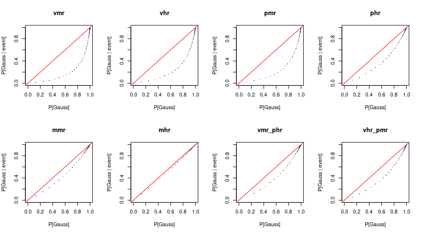

Use $1 - \text{p-value}$ from Lilliefors test as prior probability that the distribution is Gaussian.  
$x_{\text{obs}} = \min(x)$ and $P[\text{Event}\ |\ \text{Gaussian}] = P_{\text{Gauss}}[X \leq x_{\text{min}}]$:

|  | vmr | vhr | pmr | phr | mmr | mhr | vmr_phr | vhr_pmr |
| --- | --- | --- | --- | --- | --- | --- | --- | --- |
| Lillie p-val | 0.052 | 0.343 | 0.024 | 0.060 | 0.240 | 0.137 | 0.375 | 0.415 |
| Prior prob | 0.948 | 0.657 | 0.976 | 0.940 | 0.760 | 0.863 | 0.625 | 0.585 |
| P[Gauss \| Event] | 0.661 | 0.223 | 0.854 | 0.859 | 0.642 | 0.844 | 0.433 | 0.362 |

Use $1 - \text{p-value}$ from Lilliefors test as prior probability that the distribution is Gaussian.  
$x_{\text{obs}} = \max(x)$ and $P[\text{Event}\ |\ \text{Gaussian}] = P_{\text{Gauss}}[X \geq x_{\text{max}}]$:

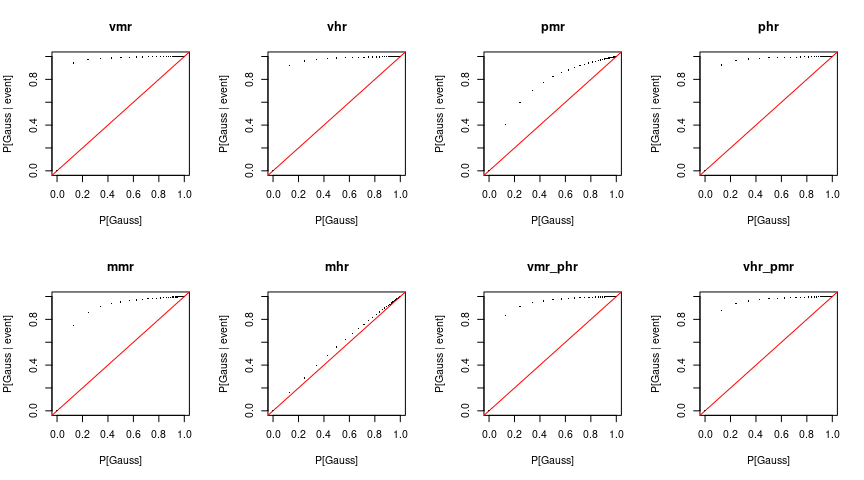

|  | vmr | vhr | pmr | phr | mmr | mhr | vmr_phr | vhr_pmr |
| --- | --- | --- | --- | --- | --- | --- | --- | --- |
| Lillie p-val | 0.052 | 0.343 | 0.024 | 0.060 | 0.240 | 0.137 | 0.375 | 0.415 |
| Prior prob | 0.948 | 0.657 | 0.976 | 0.940 | 0.760 | 0.863 | 0.625 | 0.585 |
| P[Gauss \| Event] | 1.000 | 0.993 | 0.995 | 0.999 | 0.984 | 0.888 | 0.983 | 0.986 |

# Velliv medium risk (vmr), 2011 - 2023

## QQ Plot

Skewed $t$-distribution (sstd):

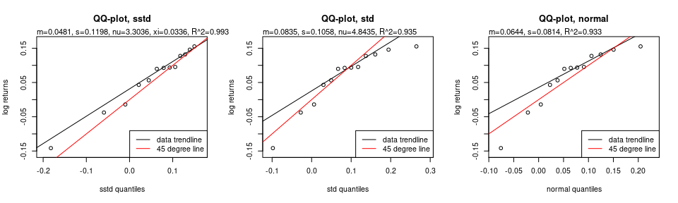

## Data vs fit

Let’s plot the fit and the observed returns together.

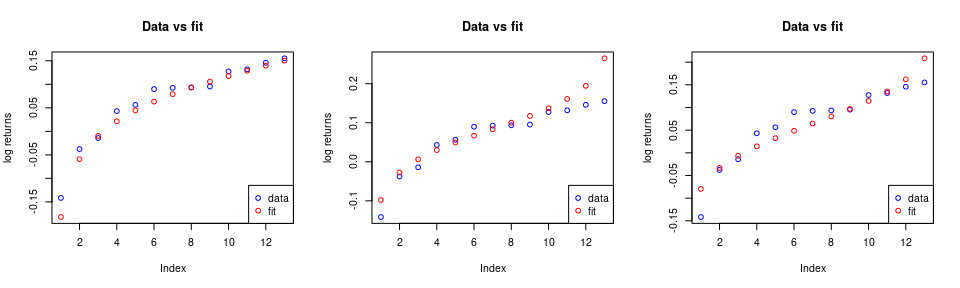

## Estimated distribution

Now lets look at the CDF of the estimated distribution for each 0.1% increment between 0.5% and 99.5% for the estimated distribution:

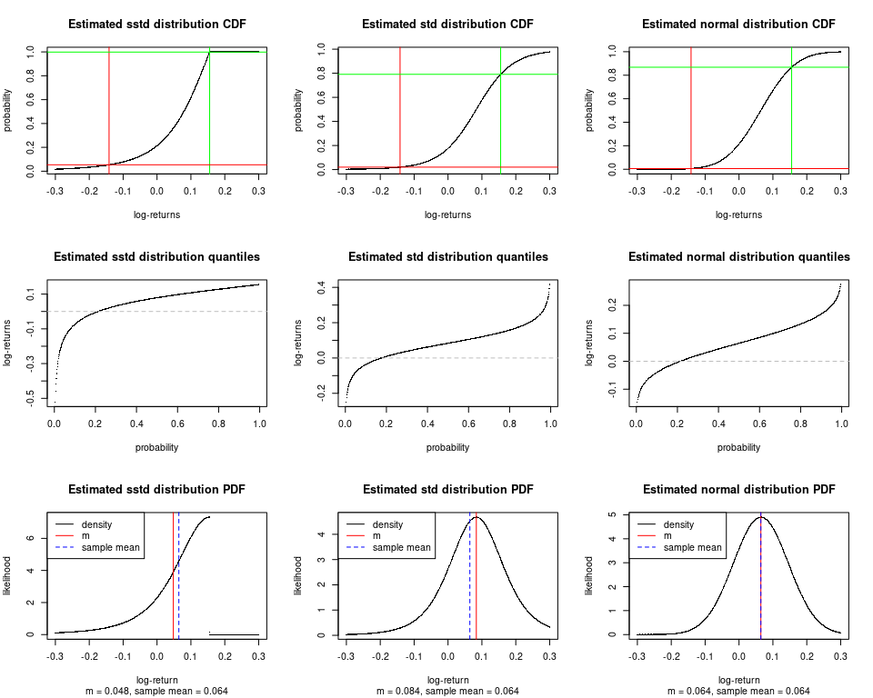

## Monte Carlo

Sorted portfolio index values for last period of all runs

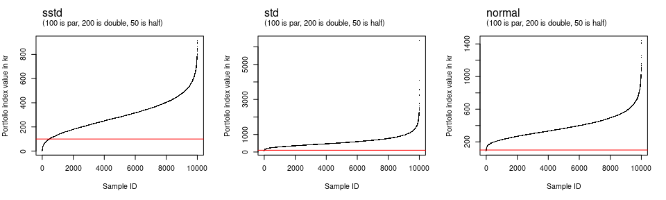

## Convergence

### Max vs sum

Max vs sum plots for the first four moments:

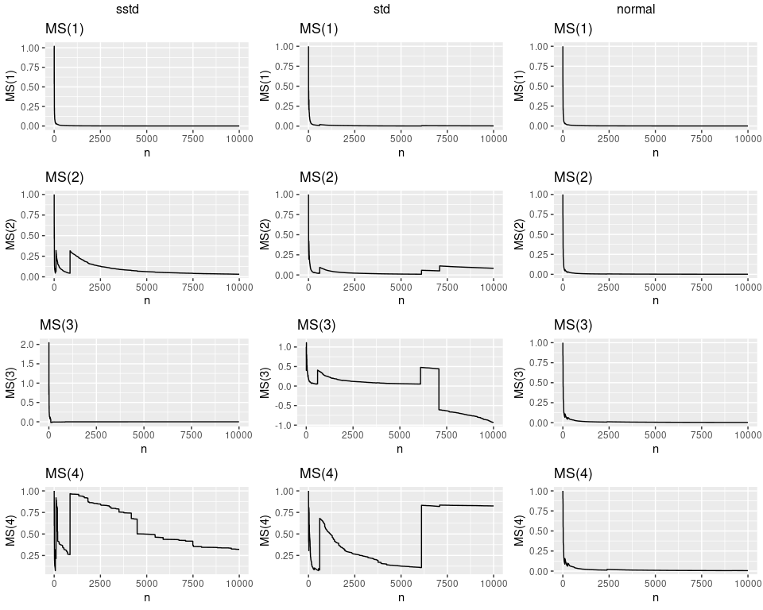

### MC

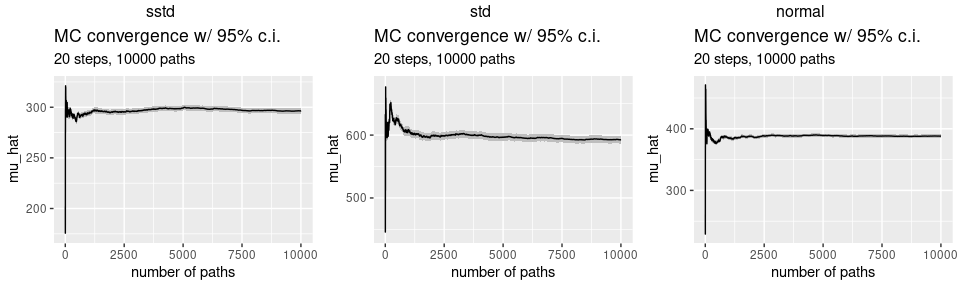

### IS

Skewed $t$-distribution with a normal proposal distribution.

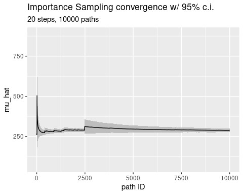

Parameters

```
## [1] 1.2294983 0.3373312
```

Objective function plots

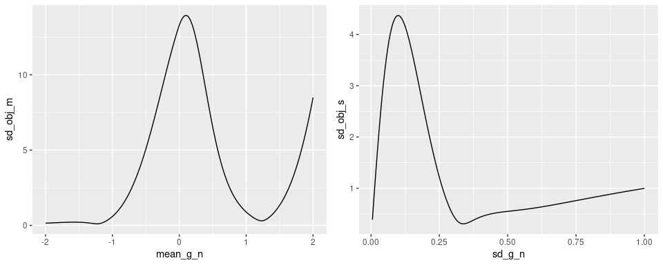

# Velliv high risk (vhr), 2011 - 2023

## QQ Plot

Skewed $t$-distribution (sstd):

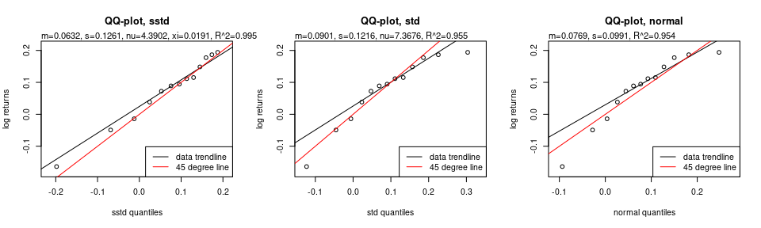

## Data vs fit

Let’s plot the fit and the observed returns together.

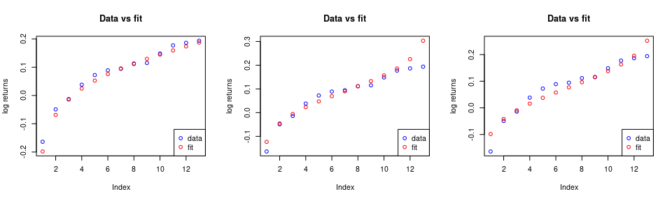

## Estimated distribution

Now lets look at the CDF of the estimated distribution for each 0.1% increment between 0.5% and 99.5% for the estimated distribution:

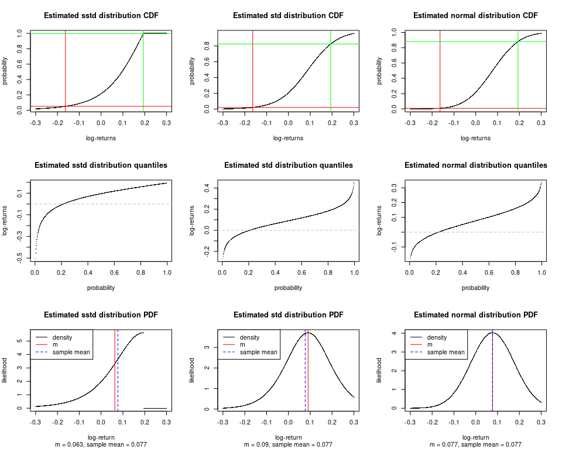

## Monte Carlo

Sorted portfolio index values for last period of all runs

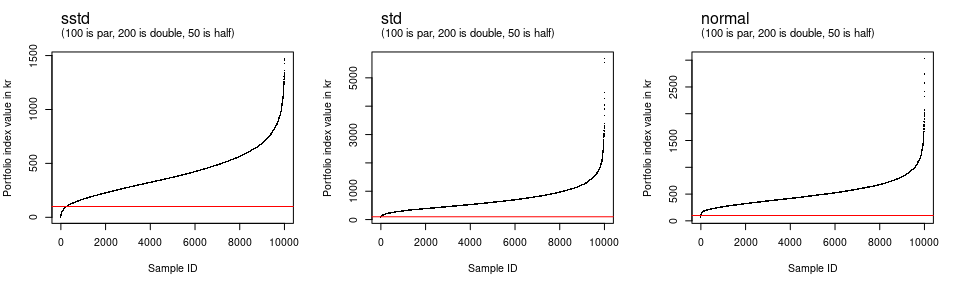

## Convergence

### Max vs sum

Max vs sum plots for the first four moments:

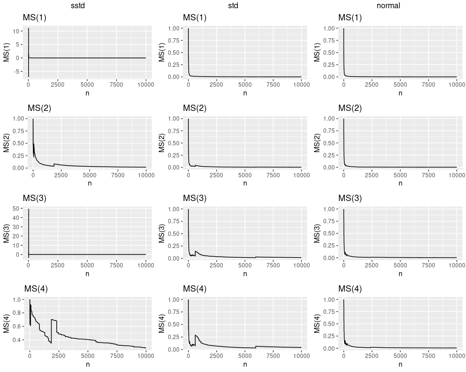

### MC

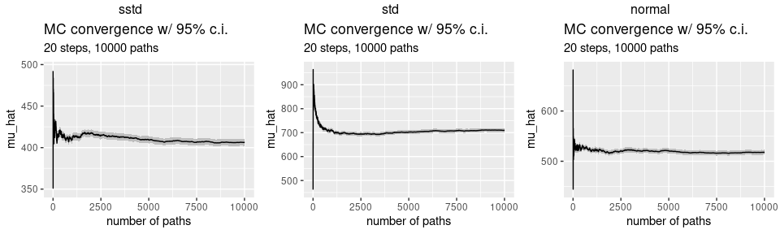

### IS

Skewed $t$-distribution with a normal proposal distribution.

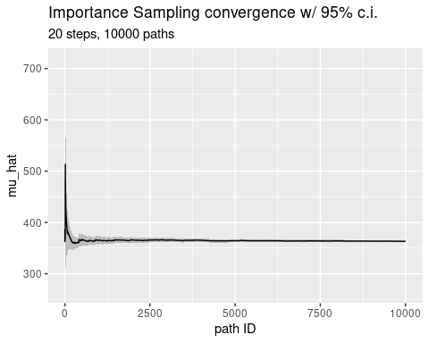

Parameters

```
## [1] 1.5074609 0.4255322
```

Objective function plots

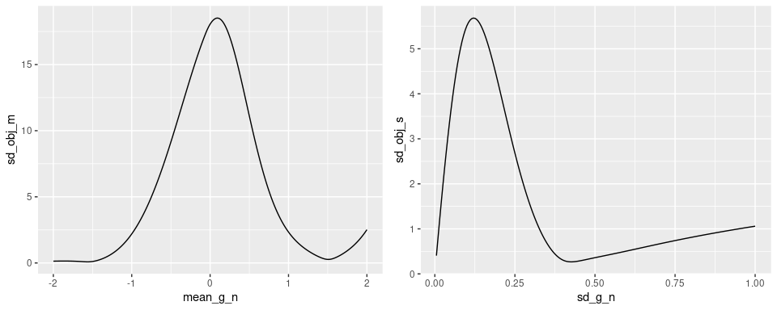

# PFA medium risk (pmr), 2011 - 2023

## QQ Plot

Skewed $t$-distribution (sstd):

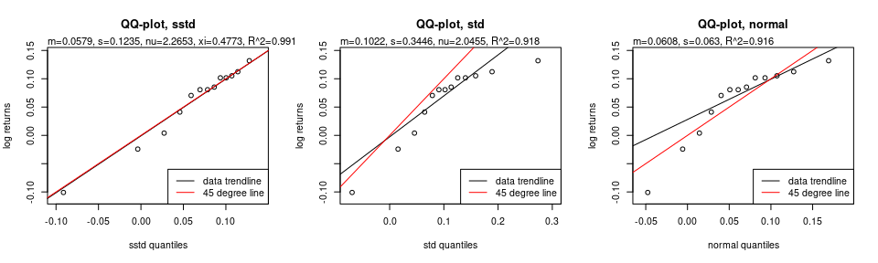

## Data vs fit

Let’s plot the fit and the observed returns together.

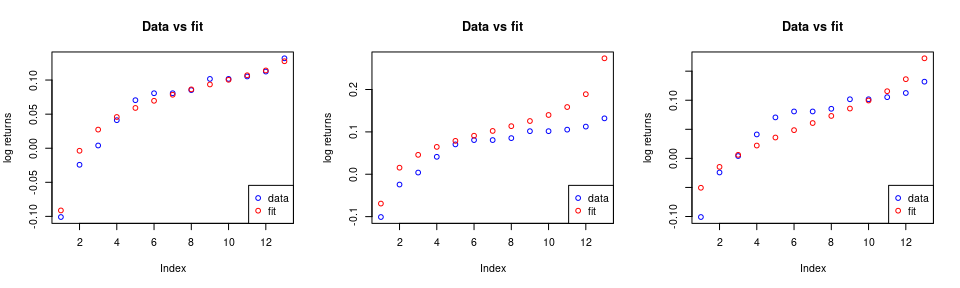

## Estimated distribution

Now lets look at the CDF of the estimated distribution for each 0.1% increment between 0.5% and 99.5% for the estimated distribution:

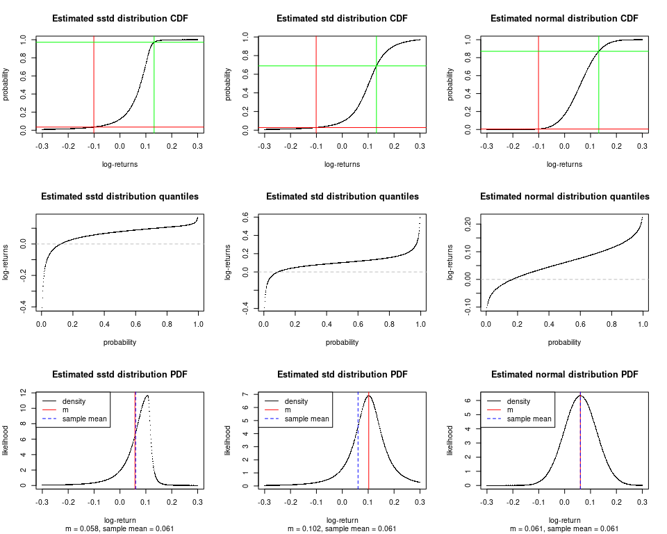

## Monte Carlo

pmr has the sstd fit with the lowest value of nu. Compare with other distributions:

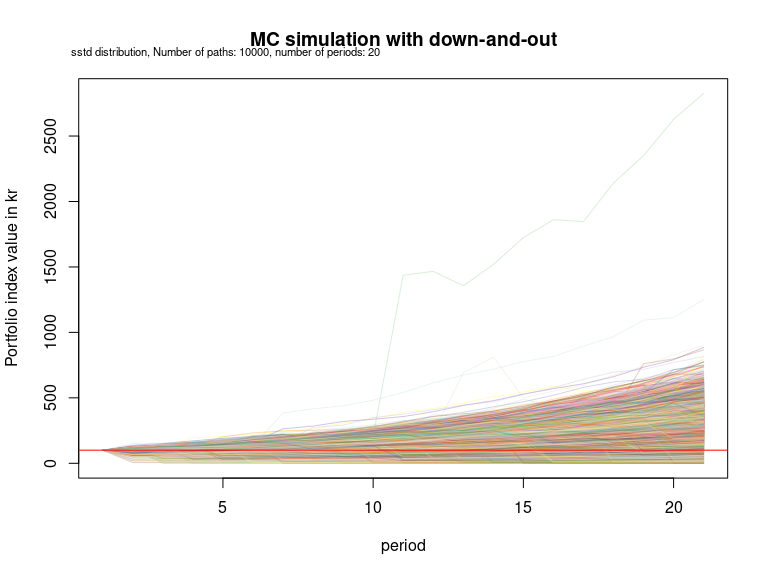

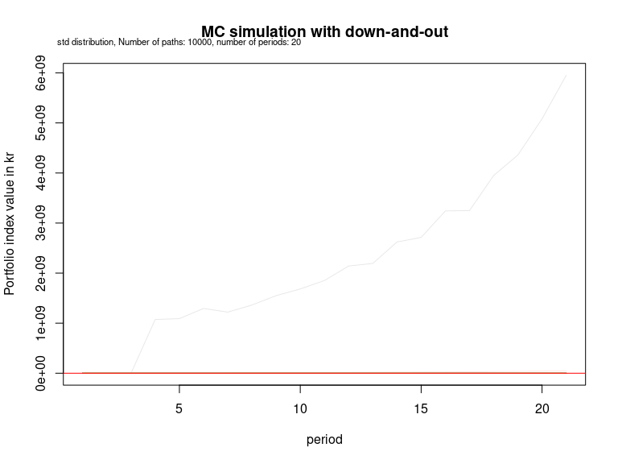

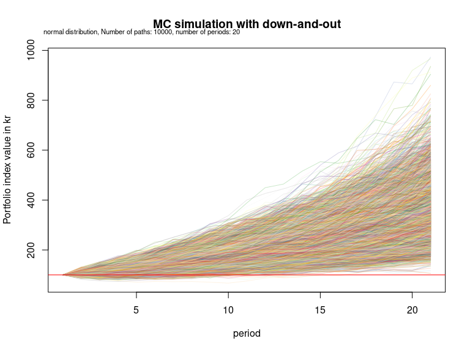

Sorted portfolio index values for last period of all runs

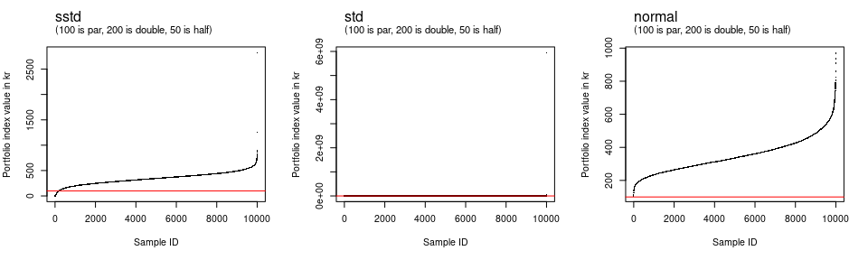

## Convergence

### Max vs sum

Max vs sum plots for the first four moments:

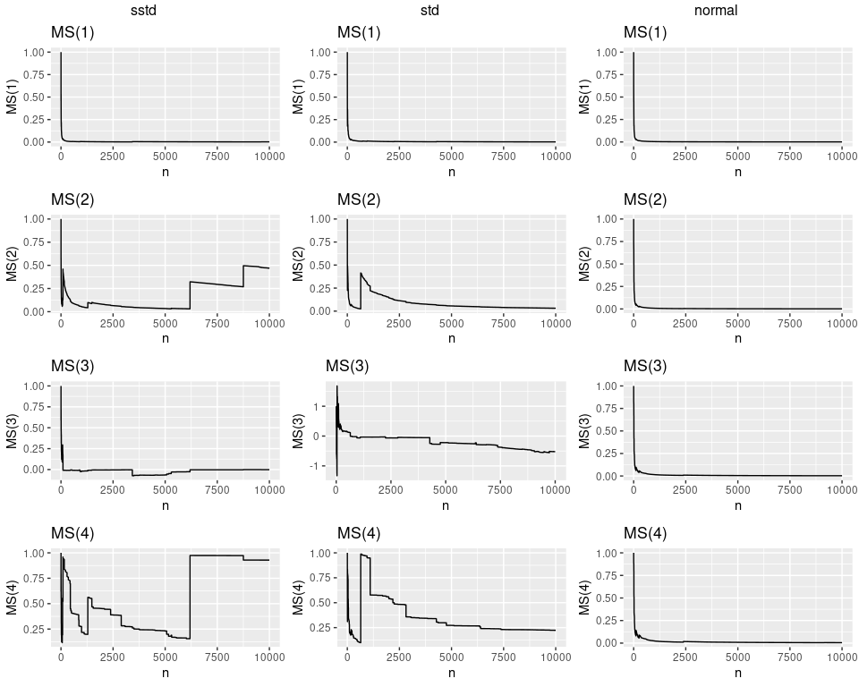

### MC

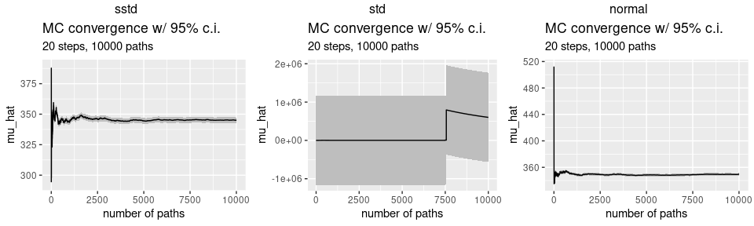

### IS

Skewed $t$-distribution with a normal proposal distribution.

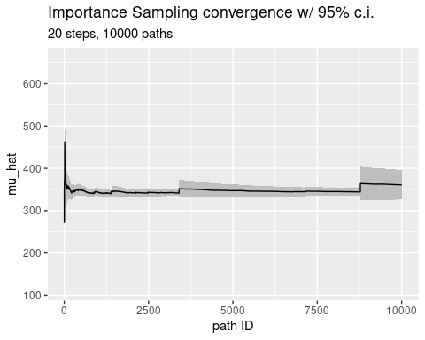

Parameters

```
## [1] 1.2936284 0.3062685
```

Objective function plots

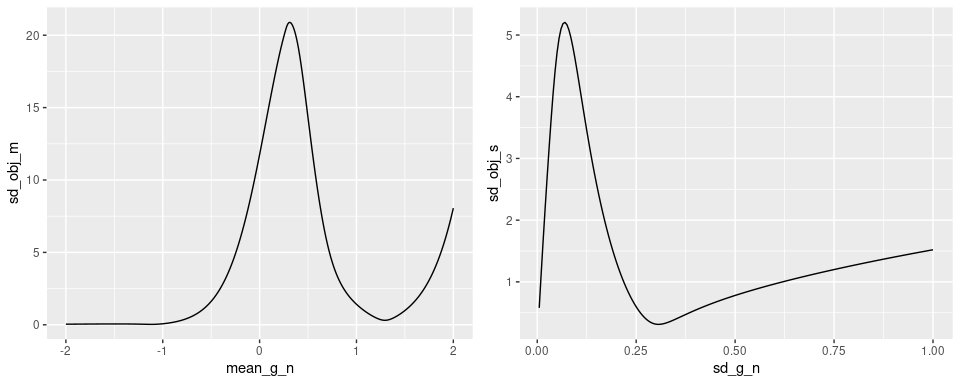